# 304.1. Cosmological Applications of Point Spread Function Analysis

For the Rubin Science Platform at data-int.lsst.cloud.  
Data Release: [Data Preview 2](https://dp2.lsst.io/)  
Container Size: *large*  
LSST Science Pipelines version: r30.0.10  
Last verified to run: 2026-07-28  
Repository: github.com/lsst/tutorial-notebooks  
DOI: 10.11578/rubin/dc.20250909.20

**Learning objective:** To use coadded PSFs in cosmological analyses.

**LSST data products:** `object`, `deep_coadd`.

**Packages:** `lsst.daf.butler`, `lsst.geom`, `treecorr`, `astropy`, `numpy`, `matplotlib`, `scipy`.

**Credit:** Originally developed by the Rubin Community Science team. Please consider acknowledging them if this notebook is used for the preparation of journal articles, software releases, or other notebooks.

**Get Support:** Everyone is encouraged to ask questions or raise issues in the [Support Category](https://community.lsst.org/c/support) of the Rubin Community Forum. Rubin staff will respond to all questions posted there.

## 1. Introduction

Accurate modeling of the Point Spread Function (PSF) is a fundamental component of modern cosmological analyses. In particular, weak gravitational lensing (cosmic shear, galaxy-galaxy lensing, and galaxy cluster mass calibration) relies on precise knowledge of the PSF to infer subtle distortions in the shapes of background galaxies. Imperfections in PSF modeling can bias shear measurements and, consequently, cosmological parameter estimation.

This notebook explores diagnostic tools and validation techniques for coadd PSF modeling using DP2 (LSSTCam) data, focusing on the galaxy cluster PSZ2 G309.43-72.86. This Sunyaev-Zel'dovich-selected cluster, at a redshift of $z = 0.35$ and with a Planck SZ mass of $M_{500c} = 5.82 \times 10^{14}\,M_\odot$, lies in the ELAIS-S1 deep drilling field.

All diagnostics here use the coadd-level `object` catalog, which provides both the measured star shapes and the PSF model shapes at the star positions.

**Related tutorials:** DP2 tutorials on the PSF in `deep_coadd` images and in `visit_image`s.

### 1.1. Import packages

Import `numpy` (numpy.org) and `matplotlib` ([matplotlib.org](https://matplotlib.org/)).

Import `treecorr`, for two-point correlation functions ([TreeCorr docs](https://rmjarvis.github.io/TreeCorr/)).

From `scipy`, import `binned_statistic`; from `astropy`, import `SkyCoord` and units; and from the LSST Science Pipelines, import the Butler and geometry utilities ([pipelines.lsst.io](https://pipelines.lsst.io/)).

```python
import numpy as np
import matplotlib.pyplot as plt
import treecorr

from scipy.stats import binned_statistic
from matplotlib.patches import Circle

from astropy.coordinates import SkyCoord
import astropy.units as u

import lsst.geom
from lsst.daf.butler import Butler
```

### 1.2. Define parameters and functions

**Function**: `get_ellipticity`

Compute the star and PSF model ellipticity components (e1, e2) from second moments.

```python
def get_ellipticity(catalog, band, obj_type='star'):
    """Compute the ellipticity components (e1, e2) from second moments
    for stars or PSF models.

    Parameters
    ----------
    catalog : `astropy.table.Table`
        Catalog containing second moment columns for the
        specified band and object type.
    band : `str`
        Photometric band (e.g., 'i', 'r') used to construct the column names.
    obj_type : `str`, optional
        Type of object: 'star' (default) or 'PSF'.

    Returns
    -------
    e1 : `np.array`
        First ellipticity component, (Ixx - Iyy) / (Ixx + Iyy).
    e2 : `np.array`
        Second ellipticity component, 2 * Ixy / (Ixx + Iyy).
    """
    if obj_type == 'star':
        suffix = ''
    elif obj_type == 'PSF':
        suffix = 'PSF'
    else:
        raise ValueError("obj_type must be either 'star' or 'PSF'.")

    ixx = catalog[f'{band}_ixx{suffix}']
    iyy = catalog[f'{band}_iyy{suffix}']
    ixy = catalog[f'{band}_ixy{suffix}']
    denom = ixx + iyy
    e1 = (ixx - iyy) / denom
    e2 = 2. * ixy / denom
    return e1, e2
```

**Function**: `compute_et`

Compute the tangential ellipticity residual in radial bins around a point.

```python
def compute_et(cat, e1_star, e2_star, e1_psf, e2_psf,
               center_ra, center_dec, r_bins):
    """Compute the tangential ellipticity residual in radial bins.

    Parameters
    ----------
    cat : `astropy.table.Table`
        Catalog with 'coord_ra' and 'coord_dec' columns (in degrees).
    e1_star, e2_star : `np.ndarray`
        Measured star ellipticity components.
    e1_psf, e2_psf : `np.ndarray`
        PSF model ellipticity components at the star positions.
    center_ra, center_dec : `float`
        Center coordinates, in degrees.
    r_bins : `array_like`
        Bin edges (in arcminutes).

    Returns
    -------
    mid : `np.ndarray`
        Midpoints of the radial bins (arcminutes).
    e_t_mean : `np.ndarray`
        Mean tangential ellipticity residual per bin.
    e_t_err : `np.ndarray`
        Standard error per bin.
    count : `np.ndarray`
        Number of objects per bin.
    """
    coord0 = SkyCoord(center_ra, center_dec, frame='icrs', unit='deg')
    coord1 = SkyCoord(cat['coord_ra'], cat['coord_dec'],
                      frame='icrs', unit='deg')

    pos_angle = coord0.position_angle(coord1).rad + np.pi / 2.
    r = coord0.separation(coord1).arcmin

    e1 = e1_star - e1_psf
    e2 = e2_star - e2_psf

    e_t = -e1 * np.cos(2. * pos_angle) - e2 * np.sin(2. * pos_angle)
    mid = 0.5 * (r_bins[1:] + r_bins[:-1])
    count, _, _ = binned_statistic(r, e_t, bins=r_bins, statistic='count')
    e_t_mean, _, _ = binned_statistic(r, e_t, bins=r_bins)
    e_t_std, _, _ = binned_statistic(r, e_t, bins=r_bins, statistic='std')
    e_t_err = e_t_std / np.sqrt(count)

    return mid, e_t_mean, e_t_err, count
```

Instantiate the Butler with the DP2 repository and collection, and get the skymap.

```python
butler = Butler('dp2', collections=['dp2'])
assert butler is not None
```

```python
skymap = butler.get('skyMap', skymap='lsst_cells_v2')
```

Define the cluster center (the Sunyaev-Zel'dovich coordinates of PSZ2 G309.43-72.86, in degrees) and the band.

```python
ra_cl, dec_cl = 10.196, -44.134
my_band = 'i'
```

Find the tract containing the cluster center.

```python
center_point = lsst.geom.SpherePoint(
    ra_cl*lsst.geom.degrees, dec_cl*lsst.geom.degrees)
my_tract = skymap.findTract(center_point).getId()
print('tract:', my_tract)
```

```
tract: 2877
```

## 2. PSF whisker plots from the `object` catalog

Whisker plots represent the shape and orientation of PSFs or galaxy ellipticities as small line segments ("whiskers") at their sky positions. Each whisker's direction encodes the ellipticity angle, and its length the ellipticity magnitude. They help visualize spatial patterns and systematics in the PSF across the field, which is essential for weak-lensing shear measurements.

Retrieve the `object` catalog for the tract, selecting the columns needed for the star and PSF model ellipticities and the flags for stars used in, and reserved from, PSF modeling.

```python
columns = ["patch", "refExtendedness",
           f"{my_band}_calib_psf_used", f"{my_band}_calib_psf_reserved",
           f"{my_band}_pixelFlags_inexact_psfCenter",
           "coord_ra", "coord_dec",
           f"{my_band}_ixx", f"{my_band}_ixxPSF",
           f"{my_band}_ixy", f"{my_band}_ixyPSF",
           f"{my_band}_iyy", f"{my_band}_iyyPSF"]
objects = butler.get("object", tract=my_tract, skymap="lsst_cells_v2",
                     parameters={"columns": columns})
```

> **Note:** Here `refExtendedness` = 0 selects point-like sources, and is used for illustration. LSST DP2 provides several derived quantities that can be used for star–galaxy separation, described in the [DP2 schema](https://sdm-schemas.lsst.io/lsstcam.html).

Define the angular separation of each object from the cluster center, and a base selection of point-like sources with a valid PSF centroid within 0.75 degrees of the center.

```python
obj_coords = SkyCoord(np.asarray(objects["coord_ra"])*u.deg,
                      np.asarray(objects["coord_dec"])*u.deg)
separation = obj_coords.separation(
    SkyCoord(ra_cl*u.deg, dec_cl*u.deg)).deg

base = ((np.asarray(objects["refExtendedness"]) == 0.0)
        & ~np.asarray(objects[f"{my_band}_pixelFlags_inexact_psfCenter"])
        & (separation < 0.75))
```

Split into stars used in, and reserved from, PSF modeling. The reserved stars are about 10 percent of the total.

```python
psf_used_table = objects[base & np.asarray(objects[f"{my_band}_calib_psf_used"])]
psf_reserved_table = objects[base & np.asarray(objects[f"{my_band}_calib_psf_reserved"])]
print(len(psf_used_table), len(psf_reserved_table))
```

```
2709 304
```

Calculate ellipticities and their Cartesian components for the used PSF models and observed stars, and the residuals.

1. For the PSF model, at the location of the `used` stars.

```python
e1_psf_used, e2_psf_used = get_ellipticity(psf_used_table, my_band, obj_type='PSF')
e_psf_used = np.sqrt(e1_psf_used**2 + e2_psf_used**2)
theta_psf_used = 0.5 * np.arctan2(e2_psf_used, e1_psf_used)
cx_psf_used = np.asarray(e_psf_used * np.cos(theta_psf_used))
cy_psf_used = np.asarray(e_psf_used * np.sin(theta_psf_used))
```

2. For the observed stars `used` in PSF modeling.

```python
e1_star_used, e2_star_used = get_ellipticity(psf_used_table, my_band, obj_type='star')
e_star_used = np.sqrt(e1_star_used**2 + e2_star_used**2)
theta_star_used = 0.5 * np.arctan2(e2_star_used, e1_star_used)
cx_star_used = np.asarray(e_star_used * np.cos(theta_star_used))
cy_star_used = np.asarray(e_star_used * np.sin(theta_star_used))
```

3. For the `reserved` stars and PSF models (used for validation below).

```python
e1_psf_res, e2_psf_res = get_ellipticity(psf_reserved_table, my_band, obj_type='PSF')
e1_star_res, e2_star_res = get_ellipticity(psf_reserved_table, my_band, obj_type='star')
```

4. The ellipticity residuals for the `used` stars.

```python
e1_residual_used = e1_star_used - e1_psf_used
e2_residual_used = e2_star_used - e2_psf_used
theta_residual_used = 0.5 * np.arctan2(e2_residual_used, e1_residual_used)
e_residual_used = np.sqrt(e1_residual_used**2 + e2_residual_used**2)
cx_residual_used = np.asarray(e_residual_used * np.cos(theta_residual_used))
cy_residual_used = np.asarray(e_residual_used * np.sin(theta_residual_used))
```

Define the plotting limits and the reference whisker, relative to the cluster center.

```python
scale = 0.6
ref_norm = scale * 0.1
ref_x, ref_y = ra_cl + 0.5, dec_cl - 0.6
ra_limits = [ra_cl + 0.55, ra_cl - 0.55]
dec_limits = [dec_cl - 0.65, dec_cl + 0.65]
x_centroid = np.asarray(psf_used_table['coord_ra'])
y_centroid = np.asarray(psf_used_table['coord_dec'])
```

Prepare the whisker data. Switch the sign of the abscissa component so RA increases to the left.

```python
whiskers = [
    (scale * -cx_star_used, scale * cy_star_used,
     f'Star ellipticity (from {my_band}_ixx, {my_band}_ixy, {my_band}_iyy)'),
    (scale * -cx_psf_used, scale * cy_psf_used,
     f'PSF model ellipticity (from {my_band}_ixxPSF, {my_band}_ixyPSF, {my_band}_iyyPSF)'),
    (scale * -cx_residual_used, scale * cy_residual_used,
     'Star - PSF ellipticity residuals')
]
```

Plot the three whisker panels side by side: measured star ellipticities, PSF model ellipticities, and star–PSF residuals, each with a reference whisker of e = 0.1.

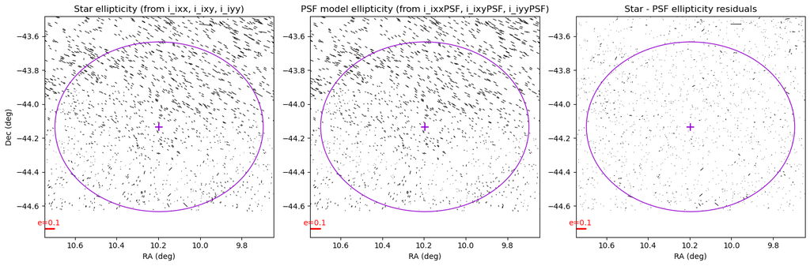

```python
fig, axes = plt.subplots(nrows=1, ncols=3, figsize=(15, 5))

for i, ax in enumerate(axes):
    cx, cy, title = whiskers[i]
    ax.quiver(x_centroid, y_centroid, cx, cy, angles='xy', color='black',
              scale_units='xy', scale=1, headlength=0, headwidth=0,
              headaxislength=0)
    ax.scatter([ra_cl], [dec_cl], marker='+', s=100, c='darkviolet')
    ax.add_patch(Circle((ra_cl, dec_cl), 0.5, color='darkviolet',
                        fill=False, linewidth=1))
    ax.quiver(ref_x, ref_y, ref_norm, 0, angles='xy', color='red',
              scale_units='xy', scale=1, headlength=0, headwidth=0,
              headaxislength=0, label=f'Ref: {ref_norm}')
    ax.text(ref_x + ref_norm / 2, ref_y + 0.02, 'e=0.1', color='red', ha='center')
    ax.invert_xaxis()
    ax.set_title(title)
    ax.set_xlabel('RA (deg)')
    ax.set_xlim(ra_limits)
    ax.set_ylim(dec_limits)
    if i == 0:
        ax.set_ylabel('Dec (deg)')

fig.tight_layout()
```

> **Figure 1:** Whisker plot for measured stars used in PSF modeling (left), PSF models from Piff ([Jarvis et al. 2021](https://ui.adsabs.harvard.edu/abs/2021MNRAS.501.1282J/abstract), center), and residuals (right) in a region with a half-degree radius around the center of PSZ2 G309.43-72.86.

Plot the histograms of the ellipticity residuals for used and reserved stars.

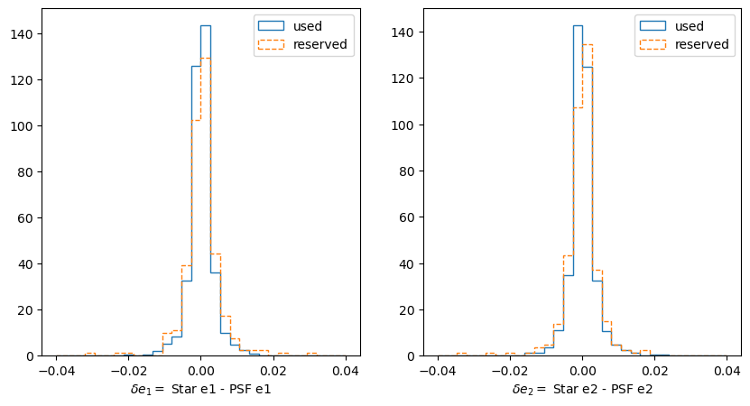

```python
fig, ax = plt.subplots(nrows=1, ncols=2, figsize=(10, 5))

ax[0].hist(np.asarray(e1_star_used - e1_psf_used), bins=30, range=[-0.04, 0.04],
           histtype='step', density=True, label='used')
ax[0].hist(np.asarray(e1_star_res - e1_psf_res), bins=30, range=[-0.04, 0.04],
           linestyle='--', histtype='step', density=True, label='reserved')
ax[0].set_xlabel(r'$\delta e_1 = $ Star e1 - PSF e1')
ax[0].legend()

ax[1].hist(np.asarray(e2_star_used - e2_psf_used), bins=30, range=[-0.04, 0.04],
           histtype='step', density=True, label='used')
ax[1].hist(np.asarray(e2_star_res - e2_psf_res), bins=30, range=[-0.04, 0.04],
           linestyle='--', histtype='step', density=True, label='reserved')
ax[1].set_xlabel(r'$\delta e_2 = $ Star e2 - PSF e2')
ax[1].legend()

plt.show()
```

> **Figure 2:** Ellipticity residuals (e1 on the left; e2 on the right) for used and reserved stars.

## 3. PSF size correlation function from the `object` catalog

Calculate the two-point correlation function of the PSF size in the chosen band, using `treecorr` and the `psf_used_table`.

```python
psf_size = np.sqrt((np.asarray(psf_used_table[f'{my_band}_ixxPSF'])
                    + np.asarray(psf_used_table[f'{my_band}_iyyPSF'])) / 2)
obj_ra = np.asarray(psf_used_table['coord_ra'])
obj_dec = np.asarray(psf_used_table['coord_dec'])
```

```python
cat = treecorr.Catalog(ra=obj_ra, dec=obj_dec,
                       k=psf_size - np.mean(psf_size),
                       ra_units='deg', dec_units='deg')
kk_config = {'max_sep': .06, 'min_sep': .0001, 'nbins': 12}
kk = treecorr.KKCorrelation(kk_config)
kk.process(cat)
xi = kk.xi
bins = kk.rnom
```

Plot the spatial map of PSF size across the field (left) and the corresponding two-point size correlation function ξ(θ) as a function of angular separation (right).

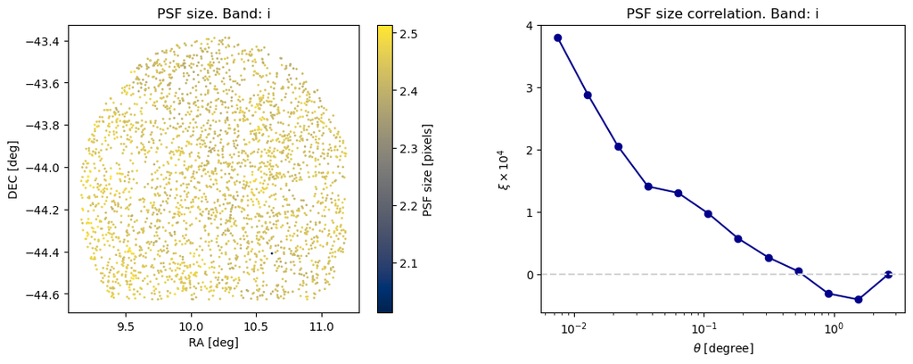

```python
_, (ax1, ax2) = plt.subplots(1, 2, figsize=(13, 4.5),
                             gridspec_kw={'wspace': .3})

ax1.set_title(f'PSF size. Band: {my_band}')
scatter_plot = ax1.scatter(obj_ra, obj_dec, c=psf_size, s=1, cmap='cividis')
ax1.set_xlabel('RA [deg]')
ax1.set_ylabel('DEC [deg]')
plt.colorbar(scatter_plot, ax=ax1, label='PSF size [pixels]')

ax2.set_title(f'PSF size correlation. Band: {my_band}')
ax2.plot(np.degrees(bins), xi*1e4, 'o-', color='darkblue')
ax2.axhline(0, linestyle='--', color='lightgrey')
ax2.set_xscale('log')
ax2.set_ylabel(r'$\xi \times 10^{4}$', labelpad=10)
ax2.set_xlabel(r'$\theta$ [degree]')

plt.show()
```

## 4. Tangential PSF ellipticity residuals around the cluster center

An important systematic check for weak lensing is whether there are significant tangential ellipticity residuals around the cluster center, using both used and reserved stars. Residual tangential patterns in the stellar ellipticities—after subtracting the PSF model—can mimic or contaminate the tangential shear signal expected around massive clusters.

Calculate the angular separation of the used stars from the cluster center, and define radial bins.

```python
r_used = SkyCoord(psf_used_table['coord_ra'], psf_used_table['coord_dec'],
                  unit='deg').separation(
    SkyCoord(ra_cl, dec_cl, unit='deg')).arcmin
r_max = np.max(r_used)
bins = np.linspace(0, r_max, 8)
```

Calculate the tangential residual for `used` stars.

```python
mid_u, e_t_u, err_u, count_u = compute_et(
    psf_used_table, e1_star_used, e2_star_used, e1_psf_used, e2_psf_used,
    ra_cl, dec_cl, bins)
```

Calculate the tangential residual for `reserved` stars.

```python
mid_r, e_t_r, err_r, count_r = compute_et(
    psf_reserved_table, e1_star_res, e2_star_res, e1_psf_res, e2_psf_res,
    ra_cl, dec_cl, bins)
```

Plot the profiles.

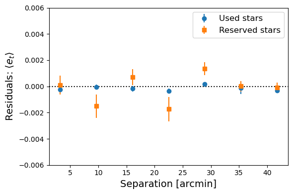

```python
plt.figure(figsize=(6, 4))
plt.errorbar(mid_u, e_t_u, err_u, fmt='o', label='Used stars')
plt.errorbar(mid_r, e_t_r, err_r, fmt='s', label='Reserved stars')
plt.axhline(0, color='k', linestyle=':')
plt.xlabel('Separation [arcmin]', fontsize=14)
plt.ylabel(r'Residuals: $\langle e_t \rangle$', fontsize=14)
plt.ylim([-0.006, 0.006])
plt.legend(fontsize=12)
plt.tight_layout()
plt.show()
```

> **Figure 4:** Tangential PSF ellipticity residuals around the center of PSZ2 G309.43-72.86, for used and reserved stars. Residuals consistent with zero indicate that the PSF modeling does not introduce a spurious tangential signal.

## 5. Exercises for the learner

1. Change `my_band` from `'i'` to `'r'` and rerun the notebook. Notice that the number of PSF stars and the amplitude of the PSF size correlation function change with the band.
2. Reduce the selection radius in Section 2 from 0.75 to 0.5 degrees and rerun. The whisker plots will cover a smaller area, and the number of stars will decrease.
3. In Section 4, change the number of radial bin edges from 8 to 5 (i.e., from 7 to 4 bins) and rerun. The tangential residual profile will have larger bins with smaller error bars per bin.